# Управление процессами

Майоров Дмитрий Андреевич

# Информация

## Докладчик

- Майоров Дмитрий Андреевич

# Цель работы

Получение навыков управления процессами операционной системы.

# Выполнение лабораторной работы

Получаем полномочия админимтратора. Вводим нужные команды

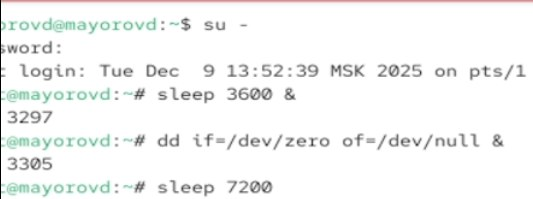

Рисунок 1

# Выполнение лабораторной работы

Вводим команду jobs. Видим три запущенныз задания. Первые два имеют состояние Running, а последнее задание в настоящее время находится в состоянии Stopped. ПЕреводим задание 3 в фоновый режим. Перемещаем задание 1 на передний план. Отменяем его. Делаем тоже самое для заданий 2 и 3.

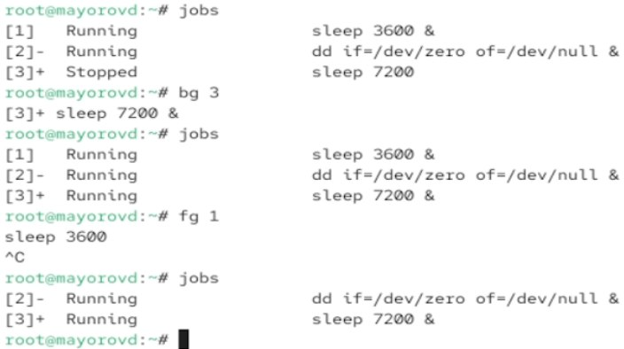

Рисунок 2: Работа с заданиями

# Выполнение лабораторной работы

Открываем второй треминал и вводим там dd if=/dev/zero of=/dev/null &. Выходим из терминала

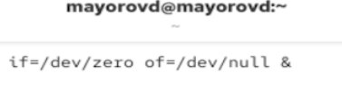

Рисунок 3

# Выполнение лабораторной работы

Запускаем 3 процесса. Используем ps aux | grep dd для просмотра всех строк где есть буквы dd.

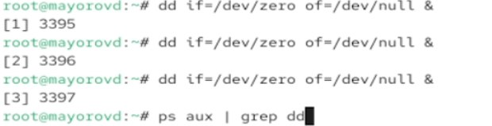

Рисунок 4

# Выполнение лабораторной работы

Изменяем приоритет одного из процессов

# Выполнение лабораторной работы

Запускаем 3 фоновых процесса.

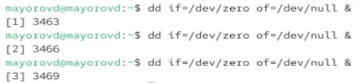

Рисунок 6

# Выполнение лабораторной работы

Увеличиваем приоритет одного из процессов на значение -5. Изменяем еще раз на значение 15. Разница в том, что -5 получает больше CPU.

# Выполнение лабораторной работы

Завершаем все процессы

# Выполнение лабораторной работы

Запускаем программу yes

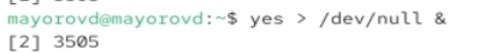

Рисунок 8

# Выполнение лабораторной работы

Переводим процесс на передний план. Потом переводим в фоновый режим. Проверяем состояние заданий командой jobs.

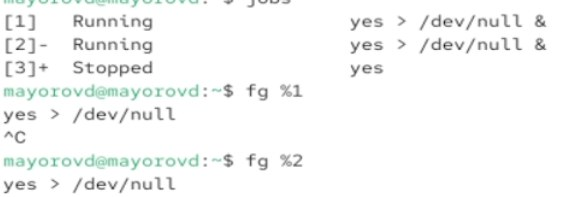

Рисунок 9

# Выполнение лабораторной работы

Запускаем процесс в фоновом режиме так, чтобы он работал даже после отключения терминала.

# Выполнение лабораторной работы

Запускаем еще три программы yes

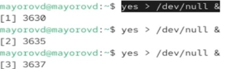

Рисунок 11

# Выполнение лабораторной работы

Убиваем два процесса используя PID и идентификатор

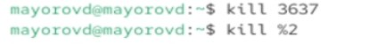

Рисунок 12

# Выполнение лабораторной работы

Завершаем их работу одновременно испольхуя killall

# Выводы

Мы получили навыки управления процессами операционной системы.